# Logistic regression

```r
library("tidyverse")
library("ggplot2")
library("dplyr")
library(GGally)
alc <- read.table("data/alc.txt")
Palette <- c("#555555", "#009E73", "#56B4E9", "#E69F00", "#F0E442", "#0072B2", "#D55E00", "#CC79A7")
```

I got some survey data from [here](https://archive.ics.uci.edu/ml/datasets/STUDENT+ALCOHOL+CONSUMPTION).

The survey questions are about students’ studying and free time from two different classes. Data has no identifier for the students but it includes many background variables that can be used to combine the data.

In the data wrangling part I also created the high alcohol consumptions variable, which will studied further in the analysis.

```r
glimpse(alc)
```

```
## Observations: 382
## Variables: 35
## $ school     <fctr> GP, GP, GP, GP, GP, GP, GP, GP, GP, GP, GP, GP, GP...
## $ sex        <fctr> F, F, F, F, F, M, M, F, M, M, F, F, M, M, M, F, F,...
## $ age        <int> 18, 17, 15, 15, 16, 16, 16, 17, 15, 15, 15, 15, 15,...
## $ address    <fctr> U, U, U, U, U, U, U, U, U, U, U, U, U, U, U, U, U,...
## $ famsize    <fctr> GT3, GT3, LE3, GT3, GT3, LE3, LE3, GT3, LE3, GT3, ...
## $ Pstatus    <fctr> A, T, T, T, T, T, T, A, A, T, T, T, T, T, A, T, T,...
## $ Medu       <int> 4, 1, 1, 4, 3, 4, 2, 4, 3, 3, 4, 2, 4, 4, 2, 4, 4, ...
## $ Fedu       <int> 4, 1, 1, 2, 3, 3, 2, 4, 2, 4, 4, 1, 4, 3, 2, 4, 4, ...
## $ Mjob       <fctr> at_home, at_home, at_home, health, other, services...
## $ Fjob       <fctr> teacher, other, other, services, other, other, oth...
## $ reason     <fctr> course, course, other, home, home, reputation, hom...
## $ nursery    <fctr> yes, no, yes, yes, yes, yes, yes, yes, yes, yes, y...
## $ internet   <fctr> no, yes, yes, yes, no, yes, yes, no, yes, yes, yes...
```

[output cut: 22 more lines]

### Examining the variables

I’ll examine students’ alcohol consumption habits with 4 other variables.

I choose address (Urban or Rural), famsize (bigger than 3 or not), Pstatus (parents living together or not) and goout (how much the student goes out).

Living area type could be somehow correlated with alcohol consumption but don’t know which way.

I would assume parents living apart would imply higher alcohol consumption.

Going out should be positively correlated obviously.

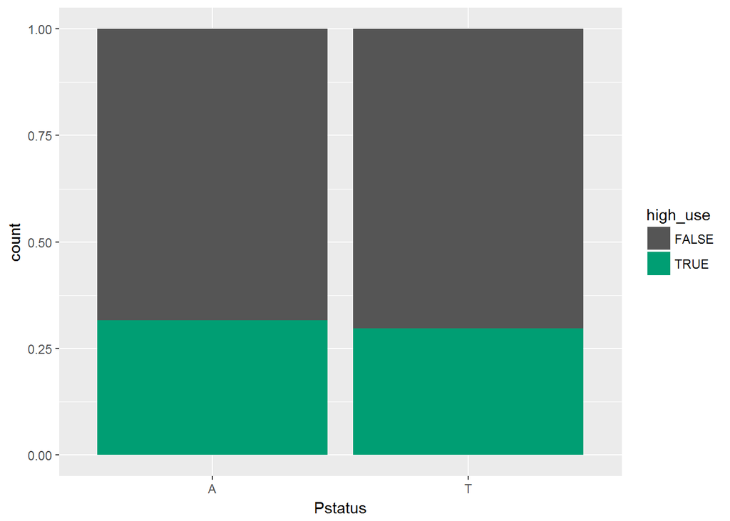

```r
g3 <- ggplot(alc, aes(x = Pstatus, fill = high_use)) + geom_bar(position="fill")
g3 + scale_fill_manual(values=Palette)
```

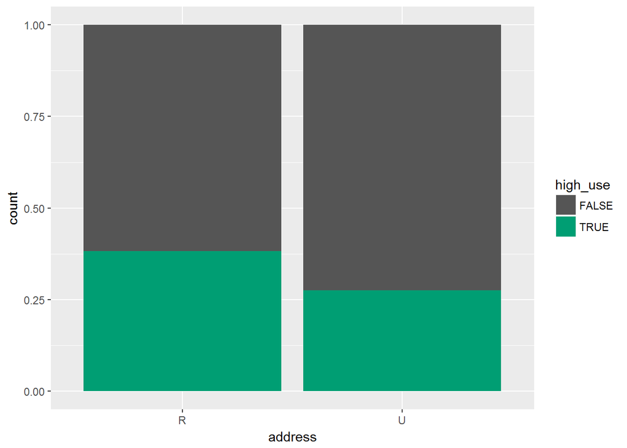

```r
g4 <- ggplot(alc, aes(x = address, fill = high_use)) + geom_bar(position="fill")
g4 + scale_fill_manual(values=Palette)
```

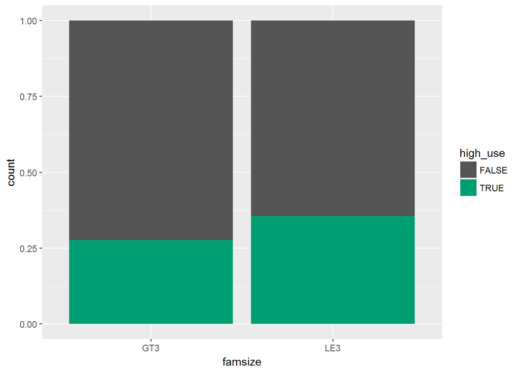

```r
g5 <- ggplot(alc, aes(x = famsize, fill = high_use)) + geom_bar(position="fill")
g5 + scale_fill_manual(values=Palette)
```

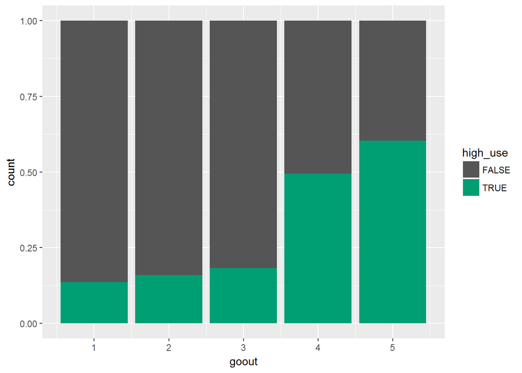

```r
g6 <- ggplot(alc, aes(x = goout, fill = high_use)) + geom_bar(position="fill")
g6 + scale_fill_manual(values=Palette)
```

```r
table(high_use = alc$high_use, address = alc$address) %>% prop.table() %>% addmargins()
```

```
##         address
## high_use          R          U        Sum
##    FALSE 0.13089005 0.57068063 0.70157068
##    TRUE  0.08115183 0.21727749 0.29842932
##    Sum   0.21204188 0.78795812 1.00000000
```

```r
table(high_use = alc$high_use, parents_living_together = alc$Pstatus) %>% prop.table() %>% addmargins()
```

```
##         parents_living_together
## high_use          A          T        Sum
##    FALSE 0.06806283 0.63350785 0.70157068
##    TRUE  0.03141361 0.26701571 0.29842932
##    Sum   0.09947644 0.90052356 1.00000000
```

```r
table(high_use = alc$high_use, familysize = alc$famsize) %>% addmargins() %>% prop.table()
```

```
##         familysize
## high_use        GT3        LE3        Sum
##    FALSE 0.13154450 0.04384817 0.17539267
##    TRUE  0.05039267 0.02421466 0.07460733
##    Sum   0.18193717 0.06806283 0.25000000
```

```r
table(high_use = alc$high_use, outgoingness = alc$goout) %>% addmargins()  %>% prop.table()
```

```
##         outgoingness
## high_use           1           2           3           4           5
##    FALSE 0.012434555 0.054973822 0.067408377 0.026832461 0.013743455
##    TRUE  0.001963351 0.010471204 0.015052356 0.026178010 0.020942408
##    Sum   0.014397906 0.065445026 0.082460733 0.053010471 0.034685864
##         outgoingness
## high_use         Sum
##    FALSE 0.175392670
##    TRUE  0.074607330
##    Sum   0.250000000
```

Living area and family size seem to have something to do with with high alcohol consumption and there’s high correlation with going out more.

### Fitting a logistic model and predictions

```r
m <- glm(high_use ~ address + Pstatus + famsize + goout, data = alc, family = "binomial")

summary(m)
```

```
##
## Call:
## glm(formula = high_use ~ address + Pstatus + famsize + goout,
##     family = "binomial", data = alc)
##
## Deviance Residuals:
##     Min       1Q   Median       3Q      Max
## -1.6006  -0.8076  -0.5978   1.0949   2.4129
##
## Coefficients:
##             Estimate Std. Error z value Pr(>|z|)
## (Intercept)  -2.8881     0.5949  -4.855 1.20e-06 ***
## addressU     -0.7584     0.2933  -2.585  0.00973 **
## PstatusT     -0.1128     0.4088  -0.276  0.78268
## famsizeLE3    0.4323     0.2691   1.606  0.10827
## goout         0.7913     0.1180   6.707 1.99e-11 ***
## ---
## Signif. codes:  0 '***' 0.001 '**' 0.01 '*' 0.05 '.' 0.1 ' ' 1
##
## (Dispersion parameter for binomial family taken to be 1)
##
##     Null deviance: 465.68  on 381  degrees of freedom
## Residual deviance: 406.88  on 377  degrees of freedom
## AIC: 416.88
##
## Number of Fisher Scoring iterations: 4
```

```r
coef(m)
```

```
## (Intercept)    addressU    PstatusT  famsizeLE3       goout
##  -2.8881308  -0.7583813  -0.1127540   0.4322526   0.7913017
```

So going out(p<0.001) and address area (p<0.01) are correlated with high alcohol consumption. Parents’ living arrangements and size of the family have really no effect.

Let’s calculate the odds ratios and confidence intervals etc.

```r
OR <- coef(m) %>% exp

CI <- exp(confint(m))

cbind(OR, CI)
```

```
##                     OR      2.5 %    97.5 %
## (Intercept) 0.05568019 0.01661415 0.1723069
## addressU    0.46842403 0.26305868 0.8338070
## PstatusT    0.89337038 0.40827321 2.0508068
## famsizeLE3  1.54072418 0.90578508 2.6084279
## goout       2.20626657 1.76160258 2.8002343
```

```r
probabilities <- predict(m, type = "response")

# add the predicted probabilities to 'alc'
alc <- mutate(alc, probability = probabilities)

# use the probabilities to make a prediction of high_use
alc <- mutate(alc, prediction = probability > 0.5)

# tabulate the target variable versus the predictions
table(high_use = alc$high_use, prediction = alc$prediction)
```

```
##         prediction
## high_use FALSE TRUE
##    FALSE   243   25
##    TRUE     73   41
```

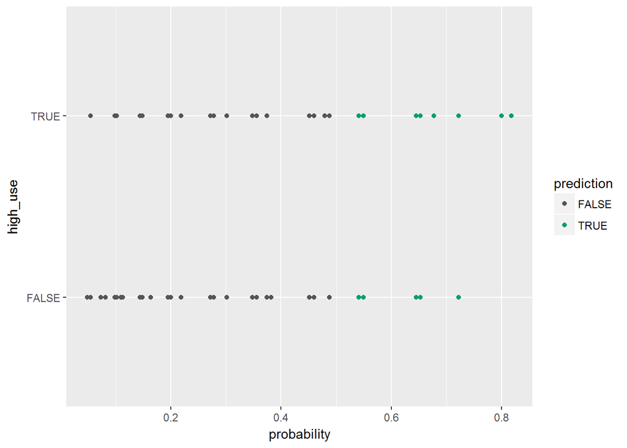

```r
# initialize a plot of 'high_use' versus 'probability' in 'alc'
g <- ggplot(alc, aes(x = probability, y = high_use, col = prediction)) + geom_point()
g + scale_colour_manual(values=Palette)
```

```r
# tabulate the target variable versus the predictions
table(high_use = alc$high_use, prediction = alc$prediction) %>% prop.table()  %>% addmargins()
```

```
##         prediction
## high_use      FALSE       TRUE        Sum
##    FALSE 0.63612565 0.06544503 0.70157068
##    TRUE  0.19109948 0.10732984 0.29842932
##    Sum   0.82722513 0.17277487 1.00000000
```

```r
loss_func <- function(class, prob) {
  n_wrong <- abs(class - prob) > 0.5
  mean(n_wrong)
}

# call loss_func to compute the average number of wrong predictions in the (training) data
loss_func(class = alc$high_use, prob = alc$probability)
```

```
## [1] 0.2565445
```

```r
library(boot)
cv <- cv.glm(data = alc, cost = loss_func, glmfit = m, K = 10)

# average number of wrong predictions in the cross validation
cv$delta[1]
```

```
## [1] 0.2565445
```